# Coursework Report

*N* removed NAs: 5

*N* removed <18: 13

*N* total clean: 149

| Group | *N* | *M*<sub>age</sub> | % green |
| --- | --- | --- | --- |
| Control | 78 | 20.6 | 54.7 |
| Experim | 71 | 21.1 | 39.0 |

| Gender | *N* | *M*<sub>age</sub> | % green |
| --- | --- | --- | --- |
| Female | 73 | 20.9 | 47.0 |
| Male | 50 | 20.9 | 50.7 |
| Other | 26 | 20.6 | 41.0 |

**Main analysis results**

**car:**  
χ<sup>2</sup>(1) = 2.9, *p* = .088

**cleaner:**  
χ<sup>2</sup>(1) = 3.78, *p* = .052

**dishwasher:**  
χ<sup>2</sup>(1) = 2.67, *p* = .102

# Coursework Report

Analysing Data, Spring 2020

# Methods

## Participants

Participant descriptives

| mean | sd | min | max |
| --- | --- | --- | --- |
| 21.2 | 1.64 | 19 | 26 |

## Design

This study examines how activating status motives influences choice between luxury ‘non-green’ products compared to less-luxurious ‘green’ products that are pro-enviroment. Both items were at equal price and non-green products were designed to look more desirable. The independent variable within this study was the use of status motives. This utilised a between-subjects experimental method with 2 separate condition dependent groups: Activated status motive or control. The data measured was the choice of product, between ‘green’ or ‘luxorious’ as separate factors.Results were also separated into another factor, product type. Participants purchased either a car, cleaner or dishwasher. Results will distinguish these purchases in bar graph format.variables were measured in levels. scores ranged depending the frequency of product chosen by each participant. With this in mind, scores could range from 0 to 99 (dependent on participant no. in each condition). High scores with each variable will represent a high freq. of purchases, a low score will represent a low freq. of purchases. It was predicted that the control condition would lead to a high frequency score of luxorious products. However activating status motives would lead a higher pruchase frequency of ‘green’ products chosen by participants.A chi-squared statistical test will be used to analyse the data.

# Results

Purchase frequency results summary

| PRODUCT | CATEGORY | CONDITION | n |
| --- | --- | --- | --- |
| dishwasher | luxury | control | 30 |
| dishwasher | luxury | experimental | 44 |
| dishwasher | green | control | 35 |
| dishwasher | green | experimental | 23 |
| car | luxury | control | 24 |
| car | luxury | experimental | 39 |
| car | green | control | 41 |
| car | green | experimental | 28 |
| cleaner | luxury | control | 28 |
| cleaner | luxury | experimental | 42 |
| cleaner | green | control | 37 |
| cleaner | green | experimental | 25 |

Results were separated by each of the 3 products, a chi-squared statisitcal analysis was conducted for each set of results to determine if there was a relationship between the experimental variables. For the ‘car’ product there was a significant association between the status motives and product category, *X*<sup>2</sup>(1) = 5.17, *p* = 0.023.

The ‘cleaner’ product also demonstrated a significant association between status motives and product category *X*<sup>2</sup>(1) = 4.34, *p* = 0.037.

Additionally a significant association between status motvies and product category was found for the ‘dishwasher’ product *X*<sup>2</sup>(1) = 4.34, *p* = 0.037. These analyses confirm that there is a significant relationship between results, but this was not the relationship that was stated in the operationalised hypothesis, as seen in the graphs presented below. Results from this study were formated into 3 separated grouped bar graphs, to provide a clear presentation of results for each product .

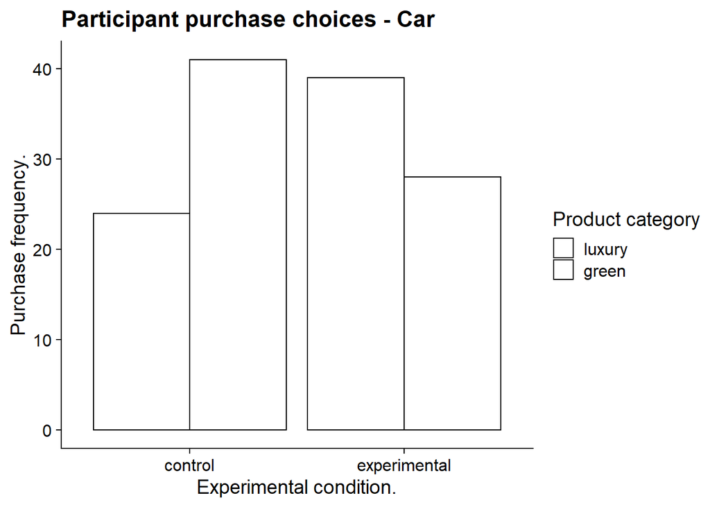

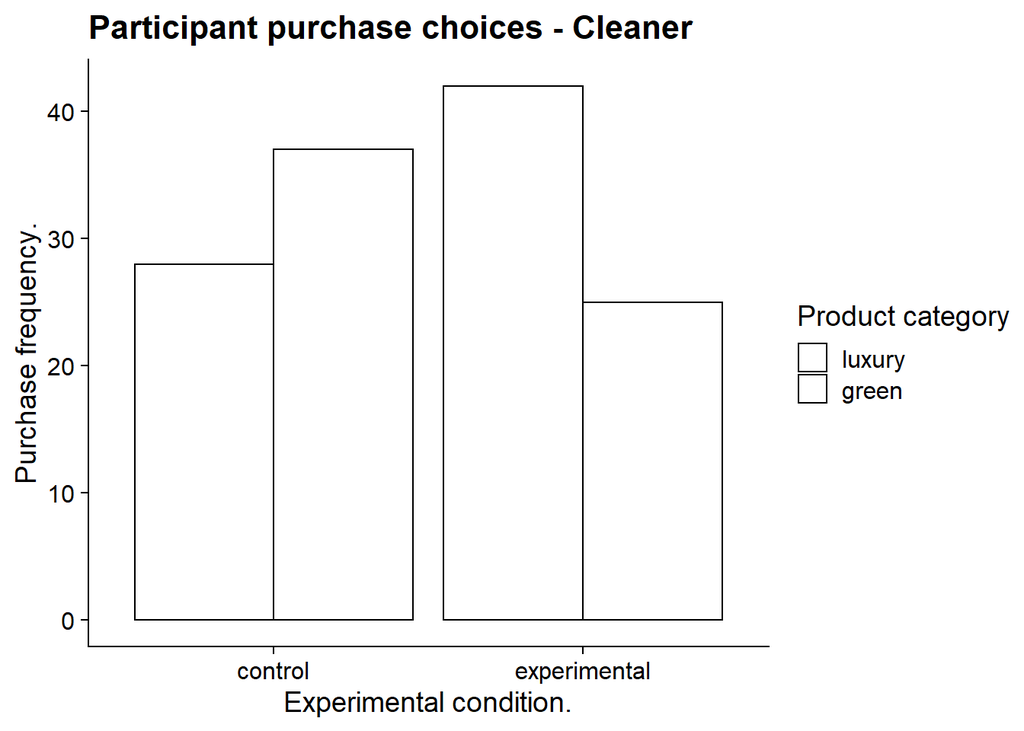

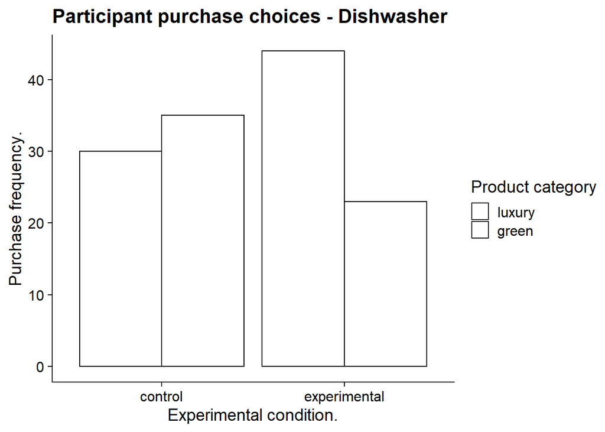

As each table demonstrates, a relationship betweeen product type purchased and use of status motives can be identified. However such results contrast to that of the null hypothesis. Participants in the experimental condition were more likely to purchase ‘luxury products’ in comparison to the control condition, wherein participants are seen to have purchased ‘green’ products more frequently. These results suggest that the predicted variable relationship is present, but opposite to what was suggested in the hypothesis.

# Discussion

As mentioned above, the results of the study suggest that the use of status motives led participants to purchase a higher number of luxury products in comparison to green products. Yet in the control condition of the study more green pruchases were made in all types of product. This conflicts to the original study and the experimental hypothesis. This reasons for this occuring could be due to a varying reasons. One of the primary suggestions for this occurence could be due to a shift in the perceptions of status(Anderson et al., 2015) and the purchase of green products. With the ‘status quo’ being that most companies aim to make their products enviromentally friendly. The majority of consumers no longer percieve a strong correlation between proenviromental products and prosocial behaviours(Griskevicius, V., Tybur, J. M., & Van Den Bergh, B. (2010)., 2013).It could be suggested that self-presentation and the investment into luxury products was due to a story of high status being read.

This could be disputed however, the original story enabling status motives still led the original participant group to pruchase a higher frequency of green products in the experimental condition. However Griskevicus noted in revised notes of the study that individual differences can have a huge impact on purchase choices(Griskevicius, V., Tybur, J. M., & Van Den Bergh, B. (2010)., 2013). The original study was largely driven by liberal individuals, whom may have percieved the status motive as an incentive to purchase the ‘green’ products(Griskevicius et al., 2010). But if the sample for this chosen experiment consisted primarily of individuals with authoritarian based mindsets then this may have had a confounding effect on results. Further studies should investigate political orientation in correspondence to the effects of status motives in order to gain a clearer idea of to what extent this could have on previous experimental results. The rise of global activism and the extinction rebellion movement may also have had an effect on participant choices(Steg et al., 2014) who fall in the authoritarian cateogry of the political compass, a rebellion against a rebellion in some aspects.

Its also worth discussing the wider implications of the study results, namely altrnative methods to help boost and maintain a wider awareness and consumption of green products. Advertisment has been considered a key element in enabling this(Hartmann & Apaolaza-Ibáñez, 2012). Marketing with a push in Enviromental experience would enable a higher purchase frequency of green products, without a push on status motives, which has decreased in effectiveness over time.

The study conducted also had its own strengths and limitations that had consequential effects on the results. Some of which have been mentioned already. The design of the participant groups for the experiment was advantageous as the control group conisited of participants that were not read a story, and participants that were read a story, but one that did not activate status motives. This was found to have the same results regardless. This ensured that there werent any confounding variables in experimental conditions, reinforcing the results as valid. In addition to this, the choice of products within the experiment was diverse and covered different categories. This was significant as this means the relationship was more likely between green products and status motives. Rather than one specific type of product. There were also areas of the study that may have lead to a less accurate validity or relaiabilty of the results. As mentioned previous the selection of participants attempted to be random, but factors such as political affiliation may have had a confounding effect on product choices, the improvement suggested for this would therefore be to take a larger sample of participants and conduct a political grid test in order to have an even distribution. A further study could specifically examine the effects of political affiliation on status motives and choosing between a green or luxury product. The study also had a small sample size, although this was in part due to the 109 removals the sample size couldnt be completely generalised to a wider population. A larger sample size would help create a more reliable generalisation.

The effects of the study should be considered as valid and suggest that there is more to explore with the reseach question, pushing for a greener more enviromentally world is a very current topic and maxisimising consumer purchases of these ‘green’ products is considered essential by many. However for future research different dimensions of the question should be analysed, including the different variables that may have an effect on purchase decisions. Such research would be useful for advertisers that want to push towards higher green product consumption.

To conclude, the main findings of this study suggest that status motives did not influence consumers to purchase ‘green’ products over ‘luxury’ products. However we did find the control group were more likely to purchase green products in the first place, we concluded that purchasing green products has become more of a status quo since the original study. But more can still be done to incresase investment into enviromentally friendly products. Further research should be focussed around what variables interact with purchase decisions and how these can be manipulated to increase green purchases.

# References

Anderson, C., Hildreth, J. A. D., & Howland, L. (2015). Is the desire for status a fundamental human motive? A review of the empirical literature. Psychological Bulletin, 141(3), 574–601. http://dx.doi.org/10.1037/a0038781

Griskevicius, V., Tybur, J. M., & Van den Bergh, B. (2010). Going green to be seen: Status, reputation, and conspicuous conservation. Journal of Personality and Social Psychology, 98(3), 392–404. https://doi.org/10.1037/a0017346

Hartmann, P., & Apaolaza-Ibáñez, V. (2012). Consumer attitude and purchase intention toward green energy brands: The roles of psychological benefits and environmental concern. Journal of Business Research, 65(9), 1254–1263. https://doi.org/10.1016/j.jbusres.2011.11.001

Steg, L., Bolderdijk, J. W., Keizer, K., & Perlaviciute, G. (2014). An Integrated Framework for Encouraging Pro-environmental Behaviour: The role of values, situational factors and goals. Journal of Environmental Psychology, 38, 104–115. https://doi.org/10.1016/j.jenvp.2014.01.002

Sundie, J. M., Kenrick, D. T., Griskevicius, V., Tybur, J. M., Vohs, K. D., & Beal, D. J. (2011). Peacocks, Porsches, and Thorstein Veblen: Conspicuous consumption as a sexual signaling system. Journal of Personality and Social Psychology, 100(4), 664–680. http://dx.doi.org/10.1037/a0021669